# What is inside Quarto in more detail

Session - What’s inside?

Zoë Turner

## How *does* Quarto work?

- 🤷
- I press `Render`, a document appears, and I believe that anything happening in between could be actual magic!
- `knitr` executes the code and converts `.qmd` to `.md`; **Pandoc** renders the `.md` file to the output format you want
- What do you think?

## Answers?

1. 🤷 ✔️
2. [“I press knit, a document appears, and I believe that anything happening in between could be actual magic.”](https://twitter.com/allison_horst/status/1070323369600442368?s=20) 🧙‍♂️)
3. `knitr` executes the code and converts `.Rmd` to `.md`; **Pandoc** renders the `.md` file to the output format you want. ✔️

https://quarto.org/docs/computations/r.html

## Metadata - YAML

*“YAML Ain’t Markup Language”*

It’s a language that isn’t R or markdown!

```yaml
---
key: value
---
```

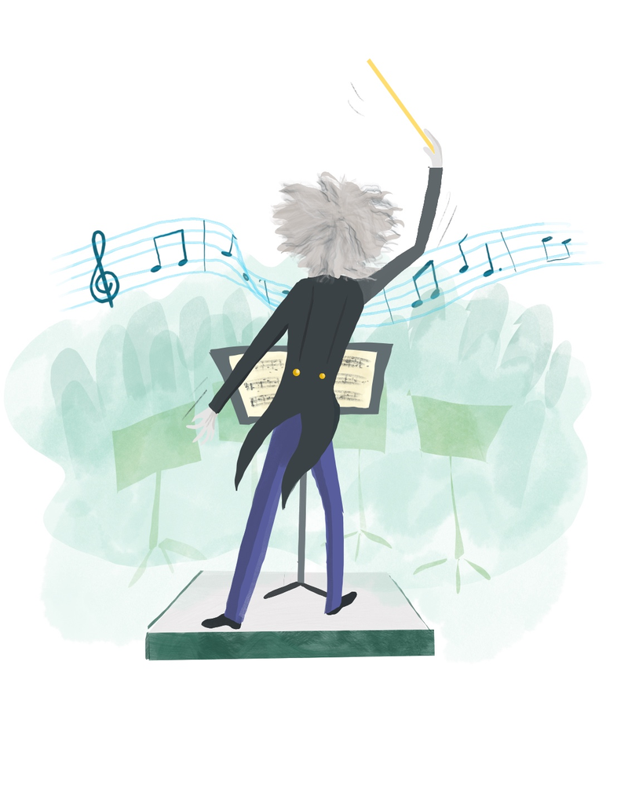

Drawn picture of the back of a conductor

## Save output options in your YAML

Basic YAML that is generated from a template

```yaml
---
title: "Report"
author: "Zoë Turner"
date: "01/08/2023"
format: html
---
```

Can be extended for certain options

```yaml
---
title: "Report"
author: "Zoë Turner"
date: "01/08/2023"
format:
  html:
    toc: true
---
```

## Your turn

In `covid-analysis.qmd` do the following:

- Add a table of contents (toc)
- Move it from the default right to the left
- Embed the source code (known as `code tools` in Quarto)

See Quarto [online documentation](https://quarto.org/docs/reference/formats/html.html) for help

*psst…answers on the next slide…*

`03:00`

## Answers

```yaml
---
title: "Untitled"
format:
  html:
    toc: true
    toc-location: left
    code-tools: true
---
```

## Embed resources (or self-contained)

- Adding `embed-resources: true` to the YAML removes a generated folder of the file name that includes supporting files.
- This makes it easier to share with others as only the html needs to be sent.
- Self contained from RMarkdown also works - Quarto is backwards compatible.

## Date formats in the YAML

Date formats in [Quarto](https://quarto.org/docs/reference/dates.html):

```markdown
date: today
date-format: "D MMMM YYYY"
```

## Dark theme

Adding a dark theme to a report is possible with the following YAML:

```markdown
format:
  html:
    theme:
      light: default
      dark: darkly
```

## Time for a break! ⏱

`10:00`

## Next Section

[figure not shown]